# Entregable 5

## FACULTAD DE CIENCIAS SOCIALES - PUCP

### Curso: POL 304 - Estadística para el análisis político 2

### Semestre 2022-1

### **REPORTE INDIVIDUAL: Entregable 5**

### **Número de grupo: Grupo 4**

### **Nombres y apellidos de la estudiante: Gabriela Eliana Rollano Málaga**

============================================================

# PRIMERA PARTE: Una explicación detallada de las variables estudiadas.

- **a. Introducción** El presente, es un reporte de Democracia de 2022 realizado por el Instituto V-Dem, el objetivo principal es que este reporte ayude a tener un mejor entendimiento de los retos que implica la democracia alrededor del mundo. Analizaremos la democracia alrededor del mundo durante el año 2021. Los niveles de democracia en el mundo suponen una baja hacia el año 2021 si se compara con otros años, debido a las dictaduras, autocracias o golpes de estado; por ello estudiaremos como va la democracia en el año 2021. Para fines de realizar este reporte, primero, trabajaremos con una variable dependiente que es el Indice de Democracia Liberal y haremos una regresión para ver la relación con sus variables independientes Autonomía de los Gobiernos Electorales, Medios de comunicación escritos o transmitidos críticos del gobierno y el Respeto a Contraargumentos. Como hipótesis tenemos que hay una relación de dependencia de estas tres variables independientes con el Indice de Democracia Liberal. Segundo, realizaremos un análisis de conglomerados para disminuir dimensiones y hacer un cálculo de cuántos clusters se van a constituir, para ello hacemos el uso de los métodos “particionante”, “jerárquica aglomerativa” y “jerárquica divisiva”, cada uno de elos nos da un número sugerido de clusters para luego visualizarlos y ver cuál es el método que mejor agrupa los casos. Para la realización de esta técnica haremos uso de seis variables independientes Autonomía de los Gobiernos Electorales, Medios de comunicación escritos o transmitidos críticos del gobierno y el Respeto a Contraargumentos, Represión gubernamental de Organizaciones de Sociedad Civil,Control gubernamental sobre Organizaciones de Sociedad Civil y Consulta gubernamental hacia Organizaciones de Sociedad Civil. Como hipótesis tenemos que a partir del gráfico de siluetas podremos ver qué técnica tiene el mayor puntaje y agrupa mejor los casos. Tercero, realizaremos un análisis factorial con las mismas seis variables con el fin de reducirlas y ver cuántos factores nos sugiere la técnica y/o están detrás del concepto de Democracia Liberal. Como hipótesis se tiene que hay un sólo factor que está detrás del comportamiento de esas 6 variables, ya que todas son parte del Indice de Democracia Liberal.
- **b. Objetivos** El objetivo es demostrar y comunicar los resultados obtenidos de estas técnicas de una manera clara, concisa y que llegue a un público no conocedor de estadística.
- **c. Explicación de la variable dependiente :** El principio liberal de la democracia enfatiza la importancia de proteger a los individuos y los derechos de las minorías frente a la tiranía del Estado y la tiranía de la mayoría. El modelo liberal adopta una visión “negativa” del poder político en la medida en que juzga la calidad de la democracia por los límites impuestos al gobierno. Esto se logra mediante las libertades civiles constitucionalmente protegidas, un Estado de derecho sólido, un poder judicial independiente y controles y equilibrios efectivos, entre otros, que en conjunto, nos permite explicar el Indice de Democracia Liberal.
- **c. Explicación de las variables independientes escogidas** Tenemos seis variables independientes y a continuación se aclara lo que significa cada una, según nuetra metadata. Autonomía de los Organismos Electorales: Los organismos electorales tienen autonomía del gobierno para aplicar leyes electorales y normas administrativas imparcialmente en las elecciones nacionales. Medios de comunicación escritos o transmitidos críticos del gobierno: De los principales medios impresos y de radiodifusión, ¿cuántos critican rutinariamente al gobierno? Respeto a Contraargumentos: Cuando se están considerando cambios de política importantes, ¿en qué medida las élites políticas reconocen y respetan los contraargumentos? Represión gubernamental de Organizaciones de Sociedad Civil: ¿El gobierno intenta reprimir a las organizaciones de la sociedad civil? Control gubernamental sobre Organizaciones de Sociedad Civil: ¿En qué medida el gobierno logra controlar la entrada y salida de la sociedad civil en la vida pública? Consulta gubernamental hacia Organizaciones de Sociedad Civil: ¿Las organizaciones de la sociedad civil más importantes son consultadas periódicamente por los encargados de la formulación de políticas sobre políticas relevantes para sus miembros?
- **d. Hipótesis** Los resultados obtenidos de estas técnicas se leen de una manera clara y concisa y son sumamente necesarios para demostrar la dependencia de las variables independientes del Indice de Democracia Liberal; así mismo se puede clusterizar para obtener menos dimensiones y se puede realizar un análisis factorial para ver cuántos factores están detrás de las seis variables.
- **1. Variable dependiente - Índice de Democracia Liberal (v2x_libdem)**

```
##    Min. 1st Qu.  Median    Mean 3rd Qu.    Max.    NA's
##  0.0050  0.0580  0.1250  0.2209  0.2920  0.8960    2619
```

```
##  num [1:27380] 0.04 0.04 0.04 0.04 0.04 0.04 0.04 0.04 0.04 0.04 ...
```

- **2. Variables independientes**
- **2.1.Autonomía de los Organismos Electorales (v2elembaut_ord)**

```
##  num [1:27380] 0 0 0 0 0 0 0 0 0 0 ...
```

```
##    Min. 1st Qu.  Median    Mean 3rd Qu.    Max.    NA's
##   0.000   0.000   0.000   1.227   3.000   4.000    3016
```

- **2.2 Medios de comunicación escritos o transmitidos críticos del gobierno (v2mecrit_ord)**

```
##  num [1:27380] 1 1 1 1 1 1 1 1 1 1 ...
```

```
##    Min. 1st Qu.  Median    Mean 3rd Qu.    Max.    NA's
##   0.000   1.000   1.000   1.397   2.000   3.000     873
```

- **2.3. Respeto a Contraargumentos (v2dlcountr_ord)**

```
##  num [1:27380] NA NA NA NA NA NA NA NA NA NA ...
```

```
##    Min. 1st Qu.  Median    Mean 3rd Qu.    Max.    NA's
##     0.0     1.0     2.0     1.6     2.0     5.0    8370
```

- **2.4. Represión gubernamental de Organizaciones de Sociedad Civil (v2csreprss_ord)**

```
##  num [1:27380] 1 1 1 1 1 1 1 1 1 1 ...
```

```
##    Min. 1st Qu.  Median    Mean 3rd Qu.    Max.    NA's
##    0.00    1.00    2.00    2.07    3.00    4.00     749
```

- **2.5. Control gubernamental sobre Organizaciones de Sociedad Civil (v2cseeorgs_ord)**

```
##  num [1:27380] 0 0 0 0 0 0 0 0 0 0 ...
```

```
##    Min. 1st Qu.  Median    Mean 3rd Qu.    Max.    NA's
##   0.000   0.000   1.000   1.597   3.000   4.000     580
```

- **2.6. Consulta gubernamental hacia Organizaciones de Sociedad Civil (v2cscnsult_ord)**

```
##  num [1:27380] 0 0 0 0 0 0 0 0 0 0 ...
```

```
##    Min. 1st Qu.  Median    Mean 3rd Qu.    Max.    NA's
##  0.0000  0.0000  0.0000  0.4807  1.0000  2.0000     554
```

# SEGUNDA PARTE: Análisis de regresión.

```
##
## Call:
## lm(formula = v2x_libdem ~ v2elembaut_ord + v2mecrit_ord + v2dlcountr_ord,
##     data = vdem_gabriela)
##
## Residuals:
##      Min       1Q   Median       3Q      Max
## -0.43385 -0.04310  0.00734  0.06330  0.24763
##
## Coefficients:
##                    Estimate Std. Error t value Pr(>|t|)
## (Intercept)       0.3505166  0.0236132  14.844  < 2e-16 ***
## v2elembaut_ord.L  0.3305202  0.0309345  10.685  < 2e-16 ***
## v2elembaut_ord.Q  0.0876921  0.0236741   3.704 0.000288 ***
## v2elembaut_ord.C -0.0005261  0.0220652  -0.024 0.981005
## v2elembaut_ord^4 -0.0131306  0.0227870  -0.576 0.565240
## v2mecrit_ord.L    0.1301965  0.0393342   3.310 0.001144 **
## v2mecrit_ord.Q    0.0597354  0.0235073   2.541 0.011965 *
## v2mecrit_ord.C    0.0069294  0.0212844   0.326 0.745166
## v2dlcountr_ord.L  0.1355787  0.0793883   1.708 0.089544 .
## v2dlcountr_ord.Q -0.0067434  0.0669633  -0.101 0.919908
## v2dlcountr_ord.C -0.0170125  0.0483010  -0.352 0.725121
## v2dlcountr_ord^4  0.0094174  0.0316134   0.298 0.766158
## v2dlcountr_ord^5  0.0121643  0.0201773   0.603 0.547417
## ---
## Signif. codes:  0 '***' 0.001 '**' 0.01 '*' 0.05 '.' 0.1 ' ' 1
##
## Residual standard error: 0.1146 on 166 degrees of freedom
## Multiple R-squared:  0.8193, Adjusted R-squared:  0.8063
## F-statistic: 62.73 on 12 and 166 DF,  p-value: < 2.2e-16
```

# ANEXOS: Análisis de regresión.

- **Observar en stargazer**

```
##
## ===============================================
##                         Dependent variable:
##                     ---------------------------
##                             v2x_libdem
## -----------------------------------------------
## v2elembaut_ord.L             0.331***
##                               (0.031)
##
## v2elembaut_ord.Q             0.088***
##                               (0.024)
##
## v2elembaut_ord.C              -0.001
##                               (0.022)
##
## v2elembaut_ord4               -0.013
##                               (0.023)
##
## v2mecrit_ord.L               0.130***
##                               (0.039)
##
## v2mecrit_ord.Q                0.060**
##                               (0.024)
##
## v2mecrit_ord.C                 0.007
##                               (0.021)
##
## v2dlcountr_ord.L              0.136*
##                               (0.079)
##
## v2dlcountr_ord.Q              -0.007
##                               (0.067)
##
## v2dlcountr_ord.C              -0.017
##                               (0.048)
##
## v2dlcountr_ord4                0.009
##                               (0.032)
##
## v2dlcountr_ord5                0.012
##                               (0.020)
##
## Constant                     0.351***
##                               (0.024)
##
## -----------------------------------------------
## Observations                    179
## R2                             0.819
## Adjusted R2                    0.806
## Residual Std. Error      0.115 (df = 166)
## F Statistic          62.731*** (df = 12; 166)
## ===============================================
## Note:               *p<0.1; **p<0.05; ***p<0.01
```

- **Comprobar supuestos de regresión lineal**
- **Linealidad**

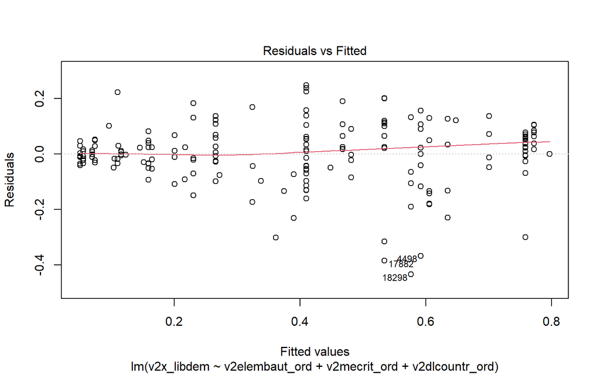

- **Homocedasticidad**

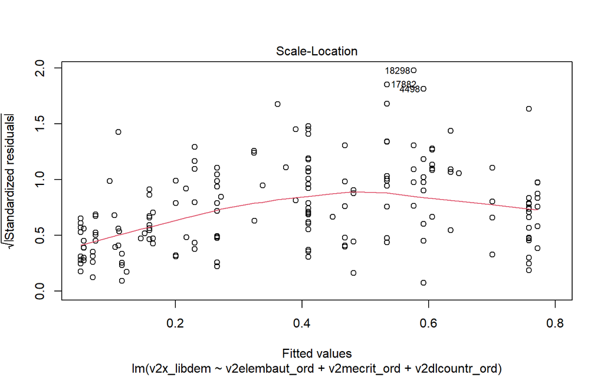

+ **Test de Breusch-Pagan**

```
##
##  studentized Breusch-Pagan test
##
## data:  modelog
## BP = 18.86, df = 12, p-value = 0.09196
```

- **Normalidad de los residuos** No hay normalidad (p-value < 0.05)

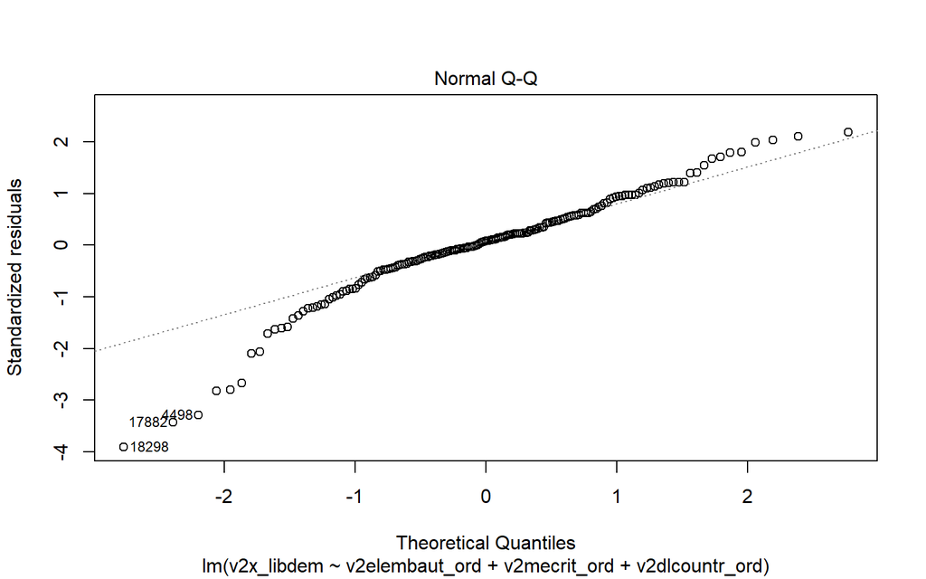

```
##
##  Shapiro-Wilk normality test
##
## data:  modelog$residuals
## W = 0.94357, p-value = 1.627e-06
```

- **No multicolinealidad**

```
##                    GVIF Df GVIF^(1/(2*Df))
## v2elembaut_ord 3.896664  4        1.185323
## v2mecrit_ord   4.128567  3        1.266582
## v2dlcountr_ord 3.690681  5        1.139490
```

- **Valores influyentes**

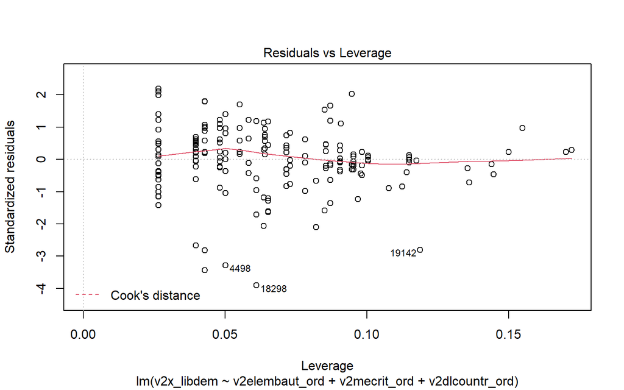

```
##      dfb.1_ dfb.v2l_.L dfb.v2l_.Q dfb.v2l_.C dfb.v2l_^4 dfb.v2m_.L dfb.v2m_.Q
## 233   FALSE      FALSE      FALSE      FALSE      FALSE      FALSE      FALSE
## 355   FALSE      FALSE      FALSE      FALSE      FALSE      FALSE      FALSE
## 588   FALSE      FALSE      FALSE      FALSE      FALSE      FALSE      FALSE
## 812   FALSE      FALSE      FALSE      FALSE      FALSE      FALSE      FALSE
## 932   FALSE      FALSE      FALSE      FALSE      FALSE      FALSE      FALSE
## 1054  FALSE      FALSE      FALSE      FALSE      FALSE      FALSE      FALSE
##      dfb.v2m_.C dfb.v2d_.L dfb.v2d_.Q dfb.v2d_.C dfb.v2d_^4 dfb.v2_^5 dffit
## 233       FALSE      FALSE      FALSE      FALSE      FALSE     FALSE FALSE
## 355       FALSE      FALSE      FALSE      FALSE      FALSE     FALSE FALSE
## 588       FALSE      FALSE      FALSE      FALSE      FALSE     FALSE FALSE
## 812       FALSE      FALSE      FALSE      FALSE      FALSE     FALSE FALSE
## 932       FALSE      FALSE      FALSE      FALSE      FALSE     FALSE FALSE
## 1054      FALSE      FALSE      FALSE      FALSE      FALSE     FALSE FALSE
##      cov.r cook.d   hat
## 233  FALSE  FALSE FALSE
## 355  FALSE  FALSE FALSE
## 588  FALSE  FALSE FALSE
## 812  FALSE  FALSE FALSE
## 932  FALSE  FALSE FALSE
## 1054 FALSE  FALSE FALSE
```

# ANEXOS: Análisis de cluster

- **Armar la base de apoyo**

```r
cluster_gabriela = subset(vdem, select = c(country_name, year, v2x_libdem, v2elembaut_ord, v2mecrit_ord, v2dlcountr_ord, v2csreprss_ord, v2cseeorgs_ord, v2cscnsult_ord))
```

```
## 'data.frame':    179 obs. of  7 variables:
##  $ country_name  : chr  "Mexico" "Suriname" "Sweden" "Switzerland" ...
##  $ v2elembaut_ord: num  4 3 4 4 3 3 3 0 0 2 ...
##  $ v2mecrit_ord  : num  2 3 3 3 2 3 3 0 1 2 ...
##  $ v2dlcountr_ord: num  2 2 4 4 2 3 4 1 1 2 ...
##  $ v2csreprss_ord: num  3 4 4 4 4 3 4 1 1 4 ...
##  $ v2cseeorgs_ord: num  3 4 4 4 4 4 4 0 1 3 ...
##  $ v2cscnsult_ord: num  0 1 2 2 2 1 1 0 0 1 ...
```

- **Hacemos la estandarización**

```
##  country_name       v2elembaut_ord     v2mecrit_ord      v2dlcountr_ord
##  Length:179         Min.   :-1.5482   Min.   :-2.34382   Min.   :-1.9144
##  Class :character   1st Qu.:-0.8571   1st Qu.:-0.04495   1st Qu.:-0.1156
##  Mode  :character   Median : 0.5251   Median :-0.04495   Median :-0.1156
##                     Mean   : 0.0000   Mean   : 0.00000   Mean   : 0.0000
##                     3rd Qu.: 0.5251   3rd Qu.: 1.10448   3rd Qu.: 0.7838
##                     Max.   : 1.2162   Max.   : 1.10448   Max.   : 2.5826
##  v2csreprss_ord    v2cseeorgs_ord    v2cscnsult_ord
##  Min.   :-2.2807   Min.   :-2.0256   Min.   :-1.45913
##  1st Qu.:-0.6445   1st Qu.:-0.8459   1st Qu.: 0.03335
##  Median : 0.1737   Median : 0.3339   Median : 0.03335
##  Mean   : 0.0000   Mean   : 0.0000   Mean   : 0.00000
##  3rd Qu.: 0.9918   3rd Qu.: 1.1205   3rd Qu.: 0.03335
##  Max.   : 0.9918   Max.   : 1.1205   Max.   : 1.52583
```

- **Vemos las correlaciones**

```
##                v2elembaut_ord v2mecrit_ord v2dlcountr_ord v2csreprss_ord
## v2elembaut_ord      1.0000000    0.7377899      0.6826106      0.7945379
## v2mecrit_ord        0.7377899    1.0000000      0.6917230      0.7422000
## v2dlcountr_ord      0.6826106    0.6917230      1.0000000      0.7146772
## v2csreprss_ord      0.7945379    0.7422000      0.7146772      1.0000000
## v2cseeorgs_ord      0.7581324    0.7667901      0.6945539      0.8888291
## v2cscnsult_ord      0.6429916    0.6375932      0.6675044      0.7144543
##                v2cseeorgs_ord v2cscnsult_ord
## v2elembaut_ord      0.7581324      0.6429916
## v2mecrit_ord        0.7667901      0.6375932
## v2dlcountr_ord      0.6945539      0.6675044
## v2csreprss_ord      0.8888291      0.7144543
## v2cseeorgs_ord      1.0000000      0.6812573
## v2cscnsult_ord      0.6812573      1.0000000
```

- **Estrategia Particionante**

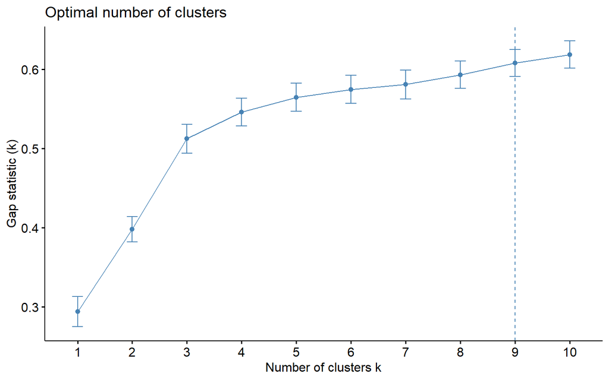

- **Estrategia Jerárquica Aglomerativa**

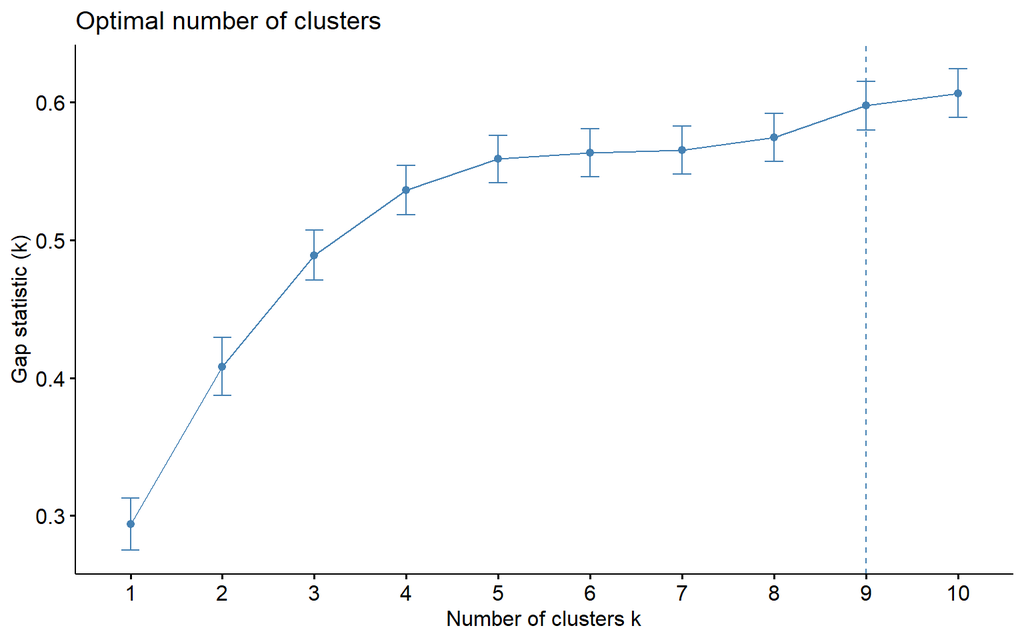

- **Estrategia Jerárquica Divisiva**

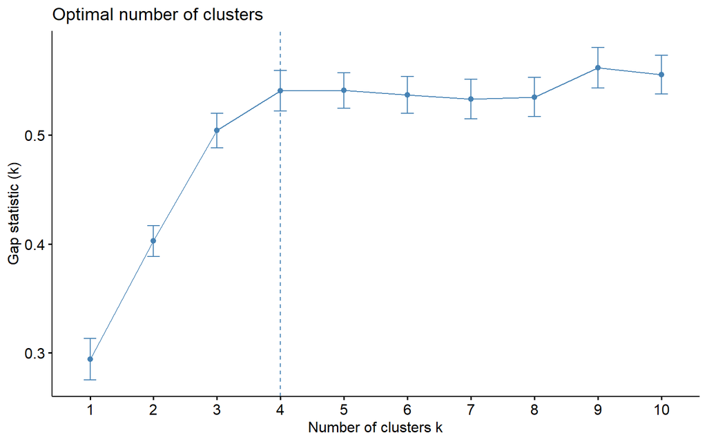

- **Evaluar resultados, para saber cuál es la estrategia que más nos conviene**
- **Se escoge el que menos casos abajo porque tienen mal ajuste. Vemos que DIANA tiene más casos abajo**

```
##   cluster size ave.sil.width
## 1       1   41          0.29
## 2       2   18          0.40
## 3       3   37          0.53
## 4       4   18          0.31
## 5       5   13          0.49
## 6       6   21          0.17
## 7       7   10          0.17
## 8       8   14          0.29
## 9       9    7          0.31
```

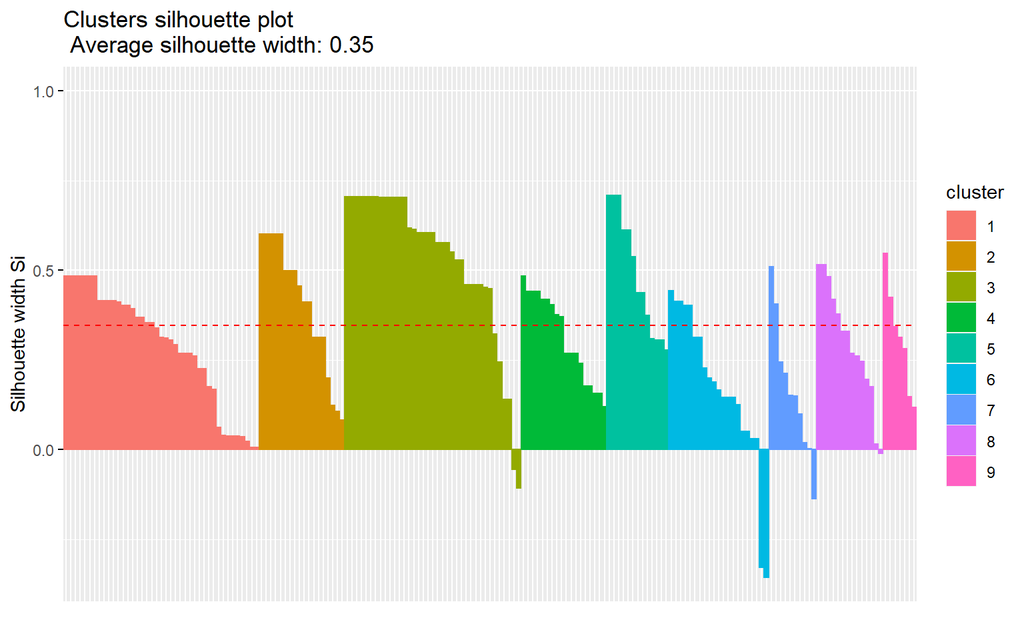

```
##   cluster size ave.sil.width
## 1       1   47          0.33
## 2       2   24          0.32
## 3       3   38          0.53
## 4       4   16          0.33
## 5       5   16          0.35
## 6       6    8          0.29
## 7       7    7          0.61
## 8       8   14          0.17
## 9       9    9          0.36
```

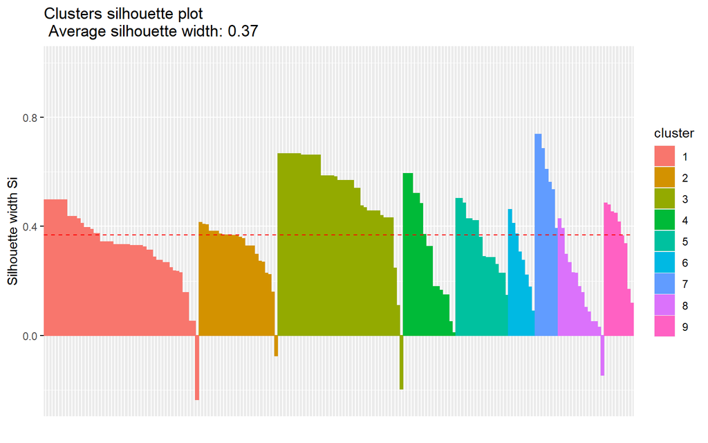

```
##   cluster size ave.sil.width
## 1       1    6          0.37
## 2       2  116          0.26
## 3       3   36          0.45
## 4       4   21          0.30
```

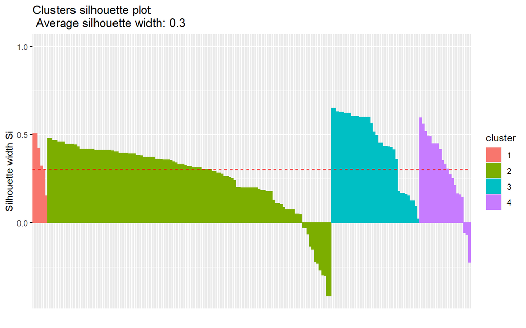

- **A partir del gráfico de siluetas, se tiene que el número sugerido para la técnica jerárquica aglomerativa es el que mayor puntuación genera, por lo tanto, es el que menos casos malagrupa**
- **Estrategia aglomerativa**
- **Es normal que salgan valores negativos porque está estandarizado, se está pidiendo la media de cada grupo por variable**

```
##   agnes v2elembaut_ord v2mecrit_ord v2dlcountr_ord v2csreprss_ord
## 1     1      0.4662717  -0.06940595      0.1140691      0.4696023
## 2     2      0.5826822   1.10448366      0.4465614      0.5827484
## 3     3      0.9433934   0.89274590      1.0205228      0.9487552
## 4     4     -1.5482422  -2.05645867     -1.5770964     -1.6671174
## 5     5     -1.2026869  -0.90702510     -1.0149693     -1.4114508
## 6     6     -0.2524098   0.24240848     -0.2279912     -0.3376513
## 7     7     -1.5482422  -0.04494992     -0.1155658     -0.2938227
## 8     8     -0.2647511  -0.04494992     -0.3082951     -0.5860131
## 9     9     -1.2410819  -1.19438349     -0.7151681     -1.0989695
##   v2cseeorgs_ord v2cscnsult_ord
## 1      0.5180281    -0.03015823
## 2      0.6288955    -0.02883511
## 3      0.8307029     1.52582886
## 4     -1.7798567    -1.36584612
## 5     -1.4357493    -1.45912596
## 6     -0.2559522    -1.45912596
## 7      0.3339463     0.03335145
## 8     -0.6773083     0.03335145
## 9     -1.1517241     0.03335145
```

- **Se reagrupa y se trata de identificar los grupos mejor posicionados**
- **Proyección de dendograma**

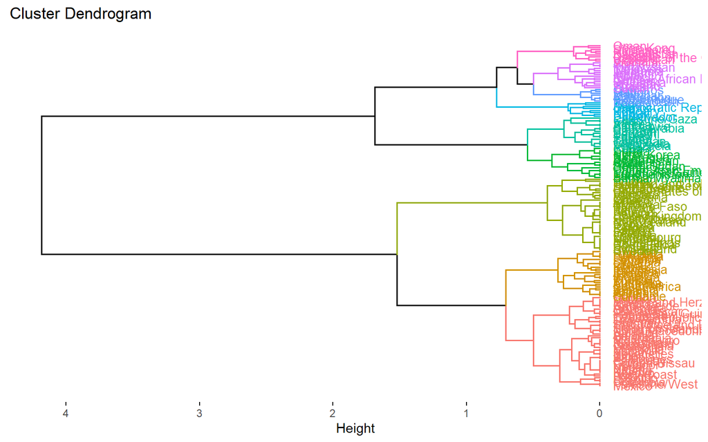

- **Estrategia basada en densidad**
- **Como nos interesa clusterizar todos los casos no vamos a usar la estrategia basada en densidad, esta es buena estrategia cuando hay escenarios en los que tenga que excluir los casos y no me conviene dejar fuera 11 cuando con la estrategia AGNES tengo la posibilidad de mal agrupar sólo a 4**

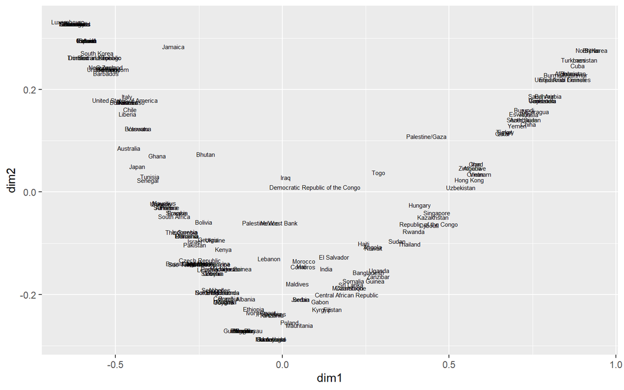

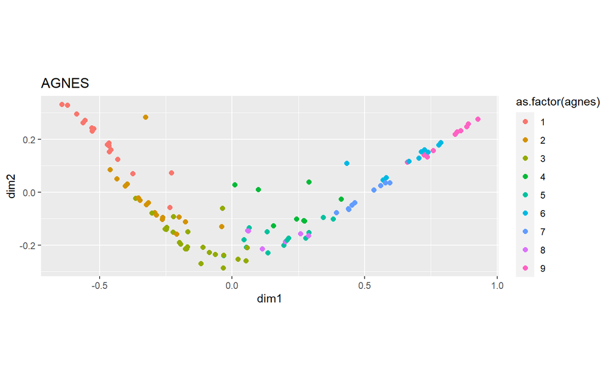

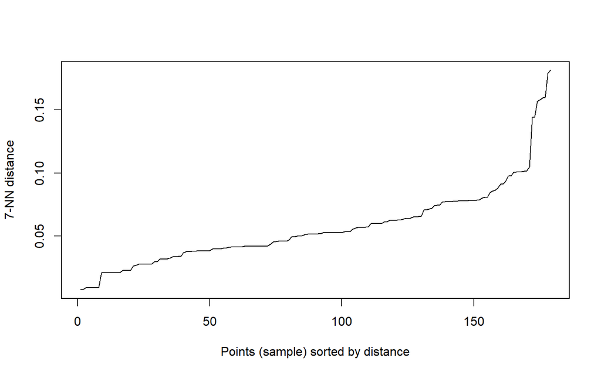

```
## dbscan Pts=179 MinPts=3 eps=0.065
##         0  1  2  3  4 5 6
## border 11  0  0  0  0 0 0
## seed    0 88 25 27 12 8 8
## total  11 88 25 27 12 8 8
```

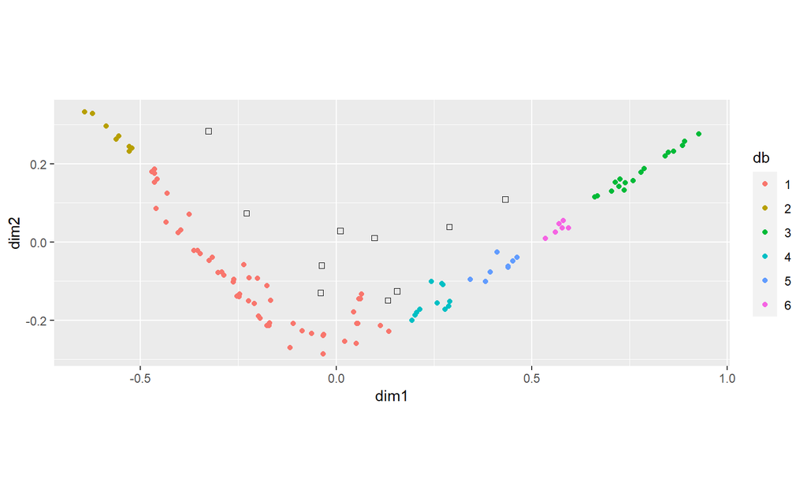

- **Se observa que son 4 los países mal agrupados**

```
##       poorPAM  poorAGNES  poorDIANA
## 1   Australia    Bolivia     Angola
## 2     Jamaica    Lebanon    Comoros
## 3   Sri Lanka Mauritania       Fiji
## 4    Thailand   Tanzania      Gabon
## 5  Uzbekistan       <NA>      Haiti
## 6     Vietnam       <NA>      India
## 7        <NA>       <NA>     Jordan
## 8        <NA>       <NA>     Kuwait
## 9        <NA>       <NA> Kyrgyzstan
## 10       <NA>       <NA>   Maldives
## 11       <NA>       <NA>       Mali
## 12       <NA>       <NA> Mauritania
## 13       <NA>       <NA>    Morocco
## 14       <NA>       <NA>     Poland
## 15       <NA>       <NA>     Serbia
```

# TERCERA PARTE: Análisis de cluster.

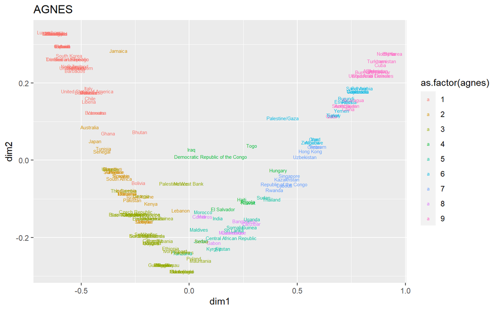

# ANEXOS: Análisis factorial

- **Armar la base de apoyo**

```r
factor_gabriela = subset(vdem, select = c(country_name, year, v2x_libdem, v2elembaut_ord, v2mecrit_ord, v2dlcountr_ord, v2csreprss_ord, v2cseeorgs_ord, v2cscnsult_ord))
```

- **Análisis Factorial Exploratorio**
- **Explorar las correlaciones entre las variables**

```
##                v2elembaut_ord v2mecrit_ord v2dlcountr_ord v2csreprss_ord
## v2elembaut_ord      1.0000000    0.7377899      0.6826106      0.7945379
## v2mecrit_ord        0.7377899    1.0000000      0.6917230      0.7422000
## v2dlcountr_ord      0.6826106    0.6917230      1.0000000      0.7146772
## v2csreprss_ord      0.7945379    0.7422000      0.7146772      1.0000000
## v2cseeorgs_ord      0.7581324    0.7667901      0.6945539      0.8888291
## v2cscnsult_ord      0.6429916    0.6375932      0.6675044      0.7144543
##                v2cseeorgs_ord v2cscnsult_ord
## v2elembaut_ord      0.7581324      0.6429916
## v2mecrit_ord        0.7667901      0.6375932
## v2dlcountr_ord      0.6945539      0.6675044
## v2csreprss_ord      0.8888291      0.7144543
## v2cseeorgs_ord      1.0000000      0.6812573
## v2cscnsult_ord      0.6812573      1.0000000
```

- **Graficar la matriz de correlaciones**

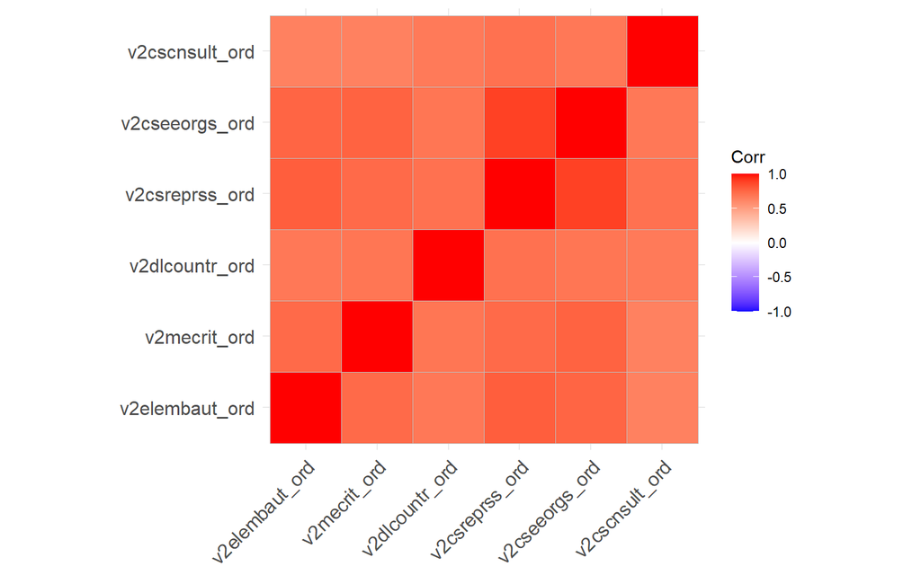

- **Verificar validez del análisis factorial**
- **Verificar si variables se pueden factorizar** Overall MSA es mayor a 0.6, por lo que el análisis factorial es factible.

```
## Kaiser-Meyer-Olkin factor adequacy
## Call: psych::KMO(r = corMatrix_g)
## Overall MSA =  0.91
## MSA for each item =
## v2elembaut_ord   v2mecrit_ord v2dlcountr_ord v2csreprss_ord v2cseeorgs_ord
##           0.93           0.93           0.94           0.85           0.86
## v2cscnsult_ord
##           0.95
```

- **Descartar una posible matriz de identidad** Sale FALSE (p-value NO es mayor a 0.05), por lo que el análisis factorial es factible.

```
## [1] FALSE
```

- **Descartar una posible matriz singular** Sale FALSE, por lo que el análisis factorial es factible.

```
## [1] FALSE
```

- **Determinar en cuántos factores se pueden agrupar las variables**

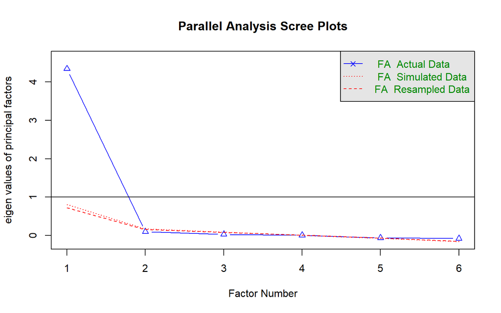

```
## Parallel analysis suggests that the number of factors =  1  and the number of components =  NA
```

- **Observar las cargas factoriales y ver en qué factores se ubicaría cada variable**

```
##
## Loadings:
##                MR1
## v2elembaut_ord 0.852
## v2mecrit_ord   0.839
## v2dlcountr_ord 0.801
## v2csreprss_ord 0.925
## v2cseeorgs_ord 0.906
## v2cscnsult_ord 0.772
##
##                  MR1
## SS loadings    4.347
## Proportion Var 0.724
```

# CUARTA PARTE: Análisis factorial

- **Graficar cómo se agrupan las variables**

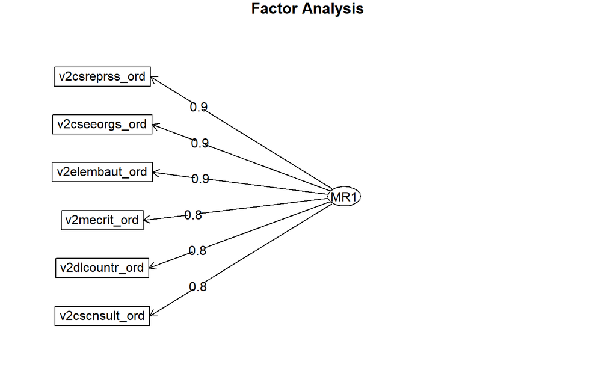

- **Evaluar los resultados obtenidos**
- **¿Qué variables aportaron más a los factores?**

```
## v2cscnsult_ord v2dlcountr_ord   v2mecrit_ord v2elembaut_ord v2cseeorgs_ord
##      0.5965095      0.6420975      0.7045047      0.7260622      0.8212054
## v2csreprss_ord
##      0.8563265
```

- **Análisis Factorial Confirmatorio**
- **Construir un modelo lineal**

```r
modelog <- ' factorg  =~ v2elembaut_ord + v2mecrit_ord + v2dlcountr_ord + v2csreprss_ord + v2cseeorgs_ord + v2cscnsult_ord'
```

- **Crear un objeto para hacer las validaciones**

```r
cfa_fit <- cfa(modelog, data=factor_gabriela,
           std.lv=TRUE,
           missing="fiml")
```

- **Preparar los test para las validaciones**

```r
allParamCFA=parameterEstimates(cfa_fit,standardized = T)
allFitCFA=as.list(fitMeasures(cfa_fit))
```

- **Ver si cada variable tiene una buena relación con su factor (p-value menor a 0.05 indica que la variable tiene buena relación con su latente)**

```
##       lhs op            rhs   est    se      z pvalue ci.lower ci.upper std.lv
## 1 factorg =~ v2elembaut_ord 1.219 0.088 13.906      0    1.048    1.391  1.219
## 2 factorg =~   v2mecrit_ord 0.715 0.054 13.356      0    0.610    0.820  0.715
## 3 factorg =~ v2dlcountr_ord 0.865 0.070 12.307      0    0.727    1.003  0.865
## 4 factorg =~ v2csreprss_ord 1.146 0.069 16.650      0    1.011    1.281  1.146
## 5 factorg =~ v2cseeorgs_ord 1.173 0.072 16.190      0    1.031    1.315  1.173
## 6 factorg =~ v2cscnsult_ord 0.509 0.043 11.907      0    0.425    0.593  0.509
##   std.all std.nox
## 1   0.845   0.845
## 2   0.824   0.824
## 3   0.780   0.780
## 4   0.940   0.940
## 5   0.925   0.925
## 6   0.762   0.762
```

- **Ver si la asignación de variables ha relativamente buena (p-value mayor a 0.05 para validar el modelo)**

```
## $chisq
## [1] 29.68009
##
## $df
## [1] 9
##
## $pvalue
## [1] 0.0004972185
```

- **Otra prueba para ver si el análisis factorial es relativamente bueno (índice Tucker - Lewi debe ser mayor a 0.9)**

```
## [1] 0.9634727
```

- **Ver si la raíz del error cuadrático medio de aproximación es menor a 0.05 (ver rmsea)**

```
## $rmsea.ci.lower
## [1] 0.06966505
##
## $rmsea
## [1] 0.1132996
##
## $rmsea.ci.upper
## [1] 0.1597871
```

- **Hacer predicciones (scores) de las variables latentes**

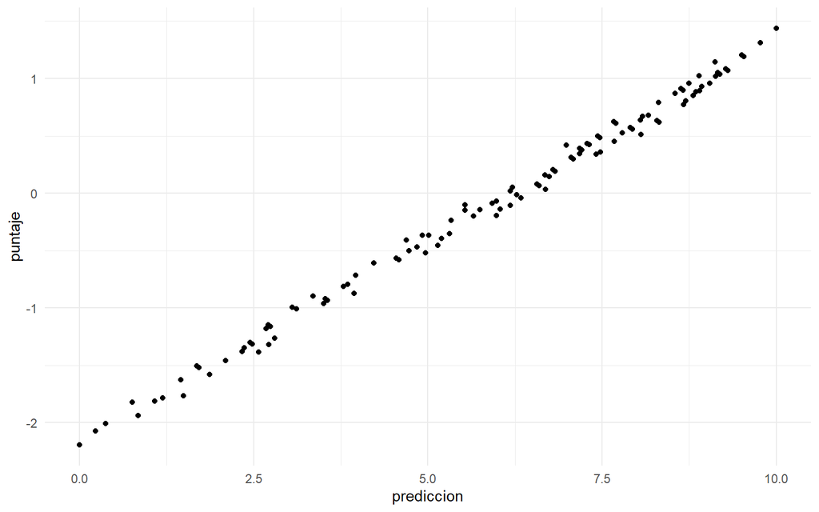

# CONCLUSIONES.

Si bien no siempre es posible identificar la causalidad directa con 100 por ciento de certeza, se puede identificar las conclusiones sobre las consecuencias y limitaciones de la gobernabilidad democrática. Por lo tanto, el presente reporte nos proporcionó evidencia gráfica sobre cuáles son las relaciones entre el Indice de democracia liberal con la Autonomía de los Gobiernos Electorales, Medios de comunicación escritos o transmitidos críticos del gobierno y el Respeto a Contraargumentos, Represión gubernamental de Organizaciones de Sociedad Civil,Control gubernamental sobre Organizaciones de Sociedad Civil y Consulta gubernamental hacia Organizaciones de Sociedad Civil.